# Assignment 2: Differential Gene Expression & Preliminary ORA

Areej Negm

#Introduction

Assignment 1 Recap & Workflow summary for Assignment 2 In the first assignment, I found an expression dataset that was of interest to me GSE157852: Human Pluripotent Stem Cell-Derived Neural Cells and Brain Organoids Reveal SARS-CoV-2 Neurotropism Predominates in Choroid Plexus Epithelium. With the raw counts provided, I proceeded to clean and filter genes that were weakly expressed (genes with counts less than n = 3) which resulted in 12849 counts. The cleaned data was then normalized using edgeR’s Trimmed Means of M-Values (TMM) method and mapped to HUGO and ensembl gene ID’s. In this assignment, I will obtain the normalized expression set and calculate p-values for each gene to determine significanlty expressed genes below the p-value threshold of 0.05. The p-values will further be corrected using a multiple hypothesis correction method then visualized with a volcano plot. \ The next step is to preform threshold over-representation analysis. \ Provided below are the visuals for the normalized expression data and an initial heatmap to better grasp the data before performing differential analysis.

```r
if (!requireNamespace("BiocManager", quietly = TRUE))
  install.packages("BiocManager")

if (!requireNamespace("Biobase", quietly = TRUE))
  install.packages("Biobase")

if (!requireNamespace("GEOmetadb", quietly = TRUE))
  BiocManager::install("GEOmetadb")

if (!requireNamespace("biomaRt", quietly = TRUE))
  BiocManager::install("biomaRt")

if (!requireNamespace("ComplexHeatmap", quietly = TRUE))
  BiocManager::install("ComplexHeatmap")

if (!requireNamespace("dplyr", quietly = TRUE))
  install.packages("dplyr")

if (!requireNamespace("edgeR", quietly = TRUE))
  install.packages("edgeR")

if (!requireNamespace("limma", quietly = TRUE))
  install.packages("limma")

if (!requireNamespace("ggplot2", quietly = TRUE))
  install.packages("ggplot2")

if (!requireNamespace("tidyr", quietly = TRUE))
  install.packages("tidyr")

if (!requireNamespace("circlize", quietly = TRUE))
  install.packages("circlize")

if (!requireNamespace("knitr", quietly = TRUE))
  install.packages("knitr")

library("knitr")
library("Biobase")
library("limma")
library("circlize")
library("ComplexHeatmap")
library("dplyr")
```

**Preparations:** Load cleaned, normalized data

```r
#saveRDS(normalized_counts, file = "normalizedClean_counts.rds")

normalized_data <- readRDS("normalizedClean_counts.rds")
```

#Visualizaton

**Normalized Density Plot**

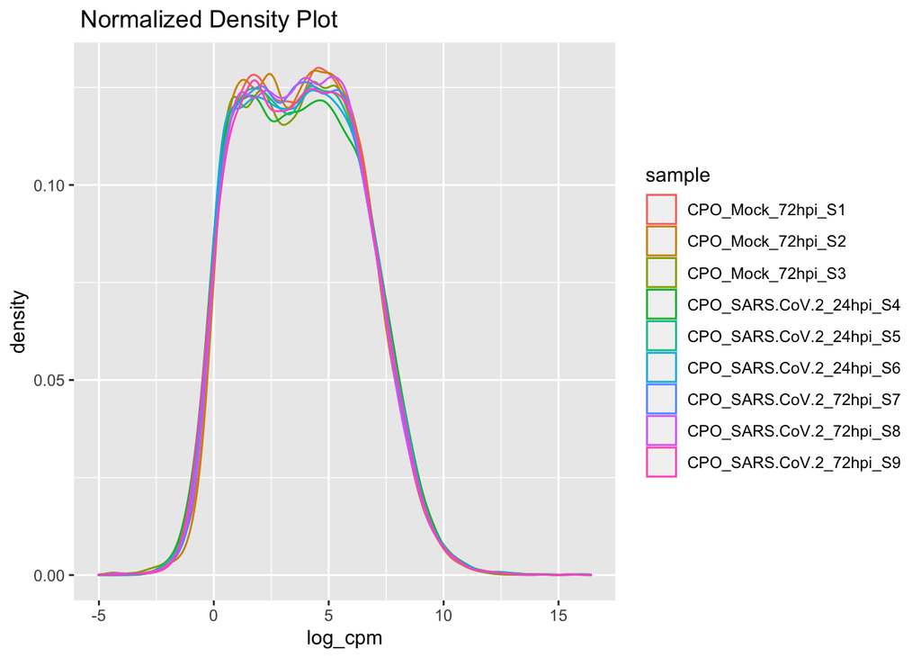

```r
normalized <- normalized_data %>%
  log2() %>%
  as.data.frame() %>%
  tidyr::gather(key=sample, value=log_cpm)

# Normalized Density plot
ggplot2::ggplot(normalized, ggplot2::aes(x=log_cpm, color=sample)) +
  ggplot2::geom_density() + ggplot2::labs(title = " Normalized Density Plot") +
  ggplot2::theme(legend.position="right")
```

**Normalized Box Plot**

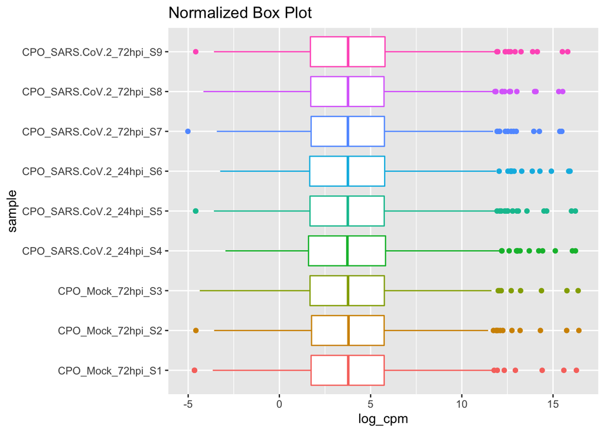

```r
#normalized box plot
ggplot2::ggplot(normalized, ggplot2::aes(x = sample, y = log_cpm,
    color = sample)) + ggplot2::geom_boxplot() + ggplot2::coord_flip() + ggplot2::labs(title = "Normalized Box Plot") +
    ggplot2::theme(legend.position = "none")
```

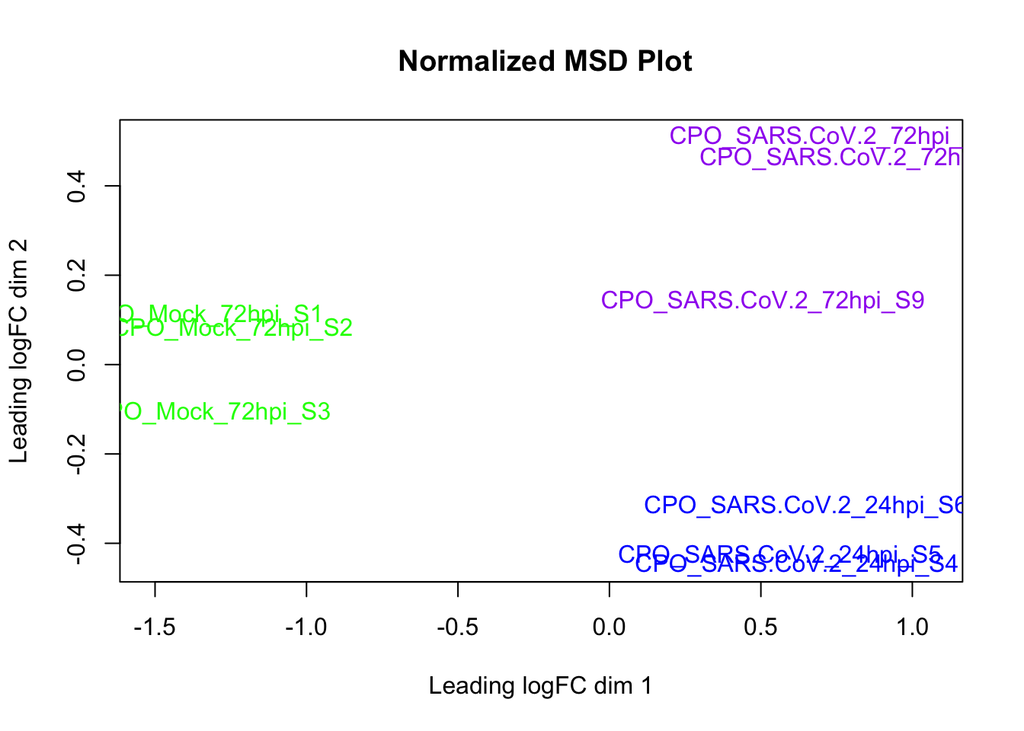

```r
#normalized MSD plot
d <- edgeR::DGEList(counts=normalized_data,
                          group=c(rep("green",3),rep("blue",3),rep("purple",3)))

edgeR::plotMDS.DGEList(d, labels=colnames(normalized_data),
               col=c(rep("green",3),rep("blue",3),rep("purple",3)),
               main=" Normalized MSD Plot")
```

**Initial HeatMap of Normalized Dataset**

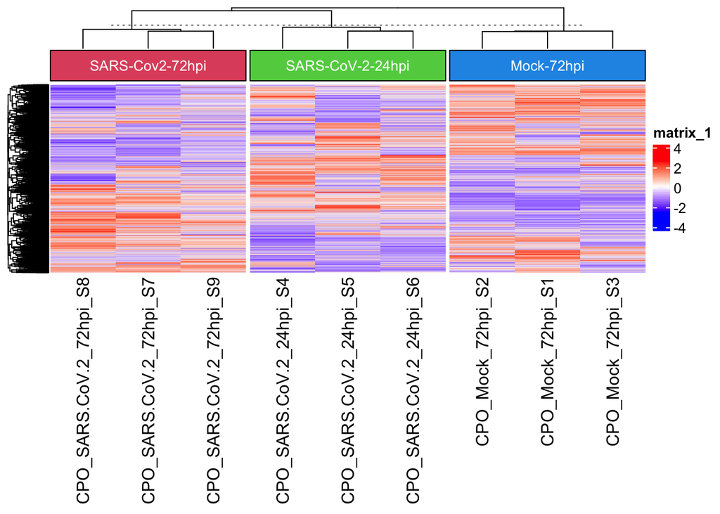

```r
heatmap_matrix <- t(scale(t(normalized_data)))

if(min(heatmap_matrix) == 0){
  heatmap_col = circlize::colorRamp2(c(min(heatmap_matrix), 0, max(heatmap_matrix)), c("blue", "white", "red"))
  } else {
    heatmap_col = circlize::colorRamp2(c(min(heatmap_matrix), 0, max(heatmap_matrix)), c("blue", "white", "red"))
  }

#heatmap annotations
haa <- ComplexHeatmap::HeatmapAnnotation(
                                   type = anno_block(gp = gpar(fill = 2:4),
                                   labels = c("SARS-Cov2-72hpi", "SARS-CoV-2-24hpi", "Mock-72hpi"),
                                   labels_gp = gpar(col = "white", fontsize = 10)))
                                   split = rep(1:3, each = 3)

initial_heatmap <- ComplexHeatmap::Heatmap(as.matrix(heatmap_matrix),
                                           show_row_dend = TRUE,
                                           show_column_dend = TRUE,
                                           col = heatmap_col,
                                           show_column_names = TRUE,
                                           show_row_names = FALSE,
                                           show_heatmap_legend = TRUE,
                                           column_split = split,
                                           top_annotation = haa,
                                           column_title = NULL)
initial_heatmap
```

#Differential Gene Expression Analysis \

**Defining Sample Types**

```r
## define samples and categorize them in their designated treatment group
samples <- data.frame(lapply(colnames(normalized_data),
FUN=function(x){unlist(strsplit(x, split = "_", 3))[c(2,3)]}))
colnames(samples) <- colnames(normalized_data)
rownames(samples) <- c("Type", "Condition") #assign groups
samples <- data.frame(t(samples))
samples$treatment <- apply(samples[, 1:2], 1, paste, collapse = "_")
```

#### 1. Calculate p-values for each of the genes in your expression set. How many genes were significantly differentially expressed? What thresholds did you use and why?

To start differential gene expression analysis, I will first create a model matrix which categorizes organoid samples based on the conditions they belong to. \ This experiment compared differentially expressed genes from the following groups, Mock-72hpi, SARS-CoV-2-24hpi and SARS-CoV-2-72hpi. Using the limma method, I first calculated a simple analysis which only took into account the types of the sample, whether it belongs to the vehicle control (Mock) or the SARS-CoV-2 group. I then performed another analysis that takes into account the differences between the SARS-CoV-2 groups, whether it is 24hpi (hours post infection) or 72hpi, which yeilded much better results that passed the p-value threshold of 0.05. 4

**Multiple Hypothesis Testing**

#### 2. Multiple hypothesis testing - correct your p-values using multiple hypothesis correction methods. Which method did you use? And Why? How many genes passed correction?

#Differential Expression Analysis: Limma method

```r
library("limma")
# Simple Limma analysis for sample type
 model_type <- model.matrix(~ samples$Type)

 expressionMatrix <- as.matrix(normalized_data)
 minimalSet <- ExpressionSet(assayData=expressionMatrix)

 fit <- limma::lmFit(minimalSet, model_type) #Fit our data to the above model

 fit2 <- limma::eBayes(fit,trend=TRUE)      # Apply Empirical Bayes to compute Differential Expression

 topfit <- limma::topTable(fit2,            # Multiple Hypothesis Testing using BH
                   coef=ncol(model_type),
                   adjust.method = "BH",
                  number = nrow(expressionMatrix))

 output_hits <- topfit[order(topfit$P.Value),]
# #Results
 length(which(output_hits$P.Value < 0.05))   # 3811
```

```
## [1] 3811
```

```r
 length(which(output_hits$adj.P.Val < 0.05)) # 1920
```

```
## [1] 1920
```

```r
# Complex Limma analysis for sample type + condition
 model <- model.matrix(~ samples$treatment)

 expressionMatrix <- as.matrix(normalized_data)
 minimalSet <- ExpressionSet(assayData=expressionMatrix)

 fit <- lmFit(minimalSet, model) #Fit our data to the above model
 fit2 <- eBayes(fit,trend=TRUE)            # Apply Empirical Bayes to compute Differential Expression
 topfit <- topTable(fit2,                  # Multiple Hypothesis Testing using BH
                    coef=ncol(model),
                    adjust.method = "BH",
                    number = nrow(expressionMatrix))

 output_hits <- topfit[order(topfit$P.Value),]
# #Results
 length(which(output_hits$P.Value < 0.05))   # 4463
```

```
## [1] 4463
```

```r
 length(which(output_hits$adj.P.Val < 0.05)) # 2600
```

```
## [1] 2600
```

#Differential Expression Analysis: Quasi Liklihood method

Further I will be using edgeR’s quasi likelihood model because my data is a bulk RNASeq dataset. This model is most commonly used for bulk RNAseq datasets as it allows for greater variablility and overdispersion in the data. With this method, I can further specify which significanly expressed genes belongs to the SARS.CoV.2-24hpi or the SARS.CoV.2-72hpi treatment groups. For the SARS.CoV.2-24hpi group, 2508 genes passed the p-value threshold and 1184 genes passed correction. For the SARS.CoV.2-72hpi group, 2477 genes passed p-value threshold, and 1340 genes passed correction.

```r
# Setting up edgeR object
library(edgeR)
dge <- edgeR::DGEList(counts=normalized_data, group=samples$treatment)
disp <- edgeR::estimateDisp(dge, model) # Estimate Dispersion
fit <- edgeR::glmQLFit(disp, model) # Fit the model

# Calculate Differential Expression for each group

#Differentially expressed genes in the SARS.CoV.2_24hpi group
qlf.Cov24hpi <- glmQLFTest(fit, coef='samples$treatmentSARS.CoV.2_24hpi')
kable(topTags(qlf.Cov24hpi), type="html",digits = 32)
```

|  | logFC | logCPM | F | PValue | FDR |
| --- | --- | --- | --- | --- | --- |
| N | 12.15517 | 13.939846 | 3989.760 | 1.102336e-19 | 1.416391e-15 |
| ORF8 | 12.17709 | 11.782785 | 2566.720 | 3.012702e-18 | 1.935511e-14 |
| S | 12.43501 | 12.829844 | 2407.981 | 4.859859e-18 | 2.081477e-14 |
| ORF7a | 12.01071 | 11.775598 | 2187.118 | 9.986677e-18 | 3.207970e-14 |
| M | 12.12220 | 12.305075 | 2070.261 | 1.506155e-17 | 3.312217e-14 |
| ORF3a | 12.46859 | 11.689128 | 2062.926 | 1.546681e-17 | 3.312217e-14 |
| ORF1ab/ORF1a | 12.35477 | 11.561458 | 1983.743 | 2.072790e-17 | 3.804754e-14 |
| ORF10 | 12.12229 | 10.888496 | 1628.942 | 9.039940e-17 | 1.451927e-13 |
| E | 12.28688 | 10.327864 | 1345.507 | 3.763578e-16 | 5.373134e-13 |
| ORF7b | 12.06746 | 9.711094 | 1305.793 | 4.705206e-16 | 5.514229e-13 |

| x |
| --- |
| BH |

| x |
| --- |
| samples$treatmentSARS.CoV.2_24hpi |

| x |
| --- |
| glm |

```r
Cov24hpifOutputHits <- topTags(qlf.Cov24hpi,sort.by = "PValue", n = nrow(normalized_data))

#How many genes passed threshold p-value < 0.05?
length(which(Cov24hpifOutputHits$table$PValue < 0.05)) #2508
```

```
## [1] 2508
```

```r
length(which(Cov24hpifOutputHits$table$FDR < 0.05)) # 1184
```

```
## [1] 1184
```

```r
#Differentially expressed genes in the SARS.CoV.2_72hpi group
qlf.Cov72hpi <- glmQLFTest(fit, coef='samples$treatmentSARS.CoV.2_72hpi')
kable(topTags(qlf.Cov72hpi), type="html",digits = 32)
```

|  | logFC | logCPM | F | PValue | FDR |
| --- | --- | --- | --- | --- | --- |
| N | 11.58274 | 13.93985 | 3665.753 | 2.081498e-19 | 2.674517e-15 |
| ORF8 | 11.52501 | 11.78279 | 2246.183 | 8.180837e-18 | 5.255779e-14 |
| S | 11.57257 | 12.82984 | 2074.745 | 1.481971e-17 | 6.347280e-14 |
| ORF7a | 11.31344 | 11.77560 | 1895.264 | 2.915695e-17 | 9.365943e-14 |
| M | 11.32189 | 12.30507 | 1781.162 | 4.637873e-17 | 1.054915e-13 |
| ORF3a | 11.72355 | 11.68913 | 1766.852 | 4.926057e-17 | 1.054915e-13 |
| ORF1ab/ORF1a | 11.30747 | 11.56146 | 1583.579 | 1.116230e-16 | 2.048920e-13 |
| ORF10 | 11.51989 | 10.88850 | 1407.894 | 2.684328e-16 | 4.311366e-13 |
| E | 11.53838 | 10.32786 | 1097.236 | 1.718707e-15 | 2.453740e-12 |
| ORF6 | 11.55389 | 10.46493 | 1057.043 | 2.268311e-15 | 2.914553e-12 |

| x |
| --- |
| BH |

| x |
| --- |
| samples$treatmentSARS.CoV.2_72hpi |

| x |
| --- |
| glm |

```r
Cov72hpiOutputHits <- topTags(qlf.Cov72hpi,sort.by = "PValue", n = nrow(normalized_data))

#How many genes passed threshold p-value < 0.05?
length(which(Cov72hpiOutputHits$table$PValue < 0.05)) #2477
```

```
## [1] 2477
```

```r
length(which(Cov72hpiOutputHits$table$FDR < 0.05)) #1340
```

```
## [1] 1340
```

#Limma vs. Quasi Based on these two analysis methods, I will stick with edgeR’s quasi- likelihood analysis because the data presented is binomially distributed, and this method is highly recommended for bulk RNASeq datasets. \

#Show the amount of differentially expressed genes using a Volcano plot **Volcano Plots**

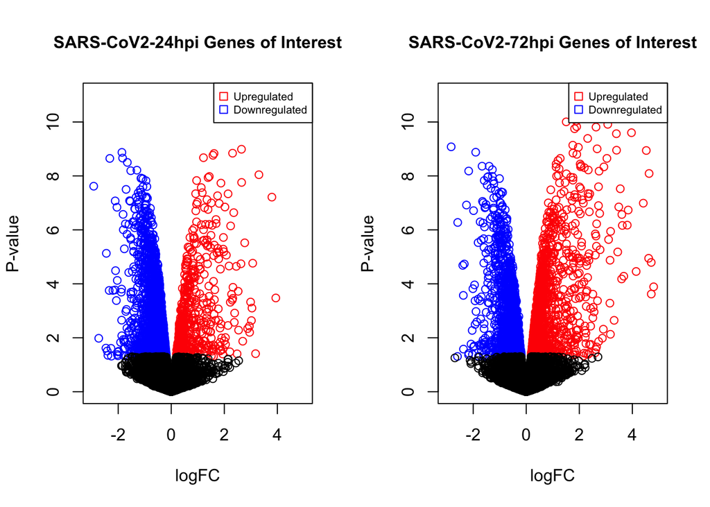

```r
par(mfrow=c(1,2), xpd=TRUE)

# volcano plot for SARS.CoV.2_24hpi
vol24hpi <- cbind(Cov24hpifOutputHits$table$logFC, -log10(Cov24hpifOutputHits$table$PValue))
colnames(vol24hpi) <- c("logFC", "P-value")
upregulated24hpi <- Cov24hpifOutputHits$table$PValue < 0.05 & Cov24hpifOutputHits$table$logFC > 0
downregulated24hpi <- Cov24hpifOutputHits$table$PValue < 0.05 & Cov24hpifOutputHits$table$logFC < 0

point.col = case_when(upregulated24hpi ~ "red",downregulated24hpi ~ "blue",TRUE ~ "black")
plot(vol24hpi, col = point.col,main="SARS-CoV2-24hpi Genes of Interest", cex.main=1, xlim = c(-3,5), ylim = c(0, 11))
legend("topright", legend=c("Upregulated", "Downregulated"), col=c("red", "blue"), pch=0.1, pt.cex = 1, cex=0.65)



# volcano plot for SARS.CoV.2_72hpi
vol72hpi <- cbind(Cov72hpiOutputHits$table$logFC, -log10(Cov72hpiOutputHits$table$PValue))
colnames(vol72hpi) <- c("logFC", "P-value")
upregulated72hpi <- Cov72hpiOutputHits$table$PValue < 0.05 & Cov72hpiOutputHits$table$logFC > 0
downregulated72hpi <- Cov72hpiOutputHits$table$PValue < 0.05 & Cov72hpiOutputHits$table$logFC < 0

point.col = case_when(upregulated72hpi ~ "red",downregulated72hpi ~ "blue",TRUE ~ "black")
plot(vol72hpi, col = point.col,main="SARS-CoV2-72hpi Genes of Interest", cex.main=1, xlim = c(-3,5), ylim = c(0, 11))
legend("topright", legend=c("Upregulated", "Downregulated"), col=c("red", "blue"), pch=0.1, pt.cex = 1, cex=0.65)
```

##Visualize your top hits using a heatmap. Do you conditions cluster together? Explain why or why not. **HeatMap**

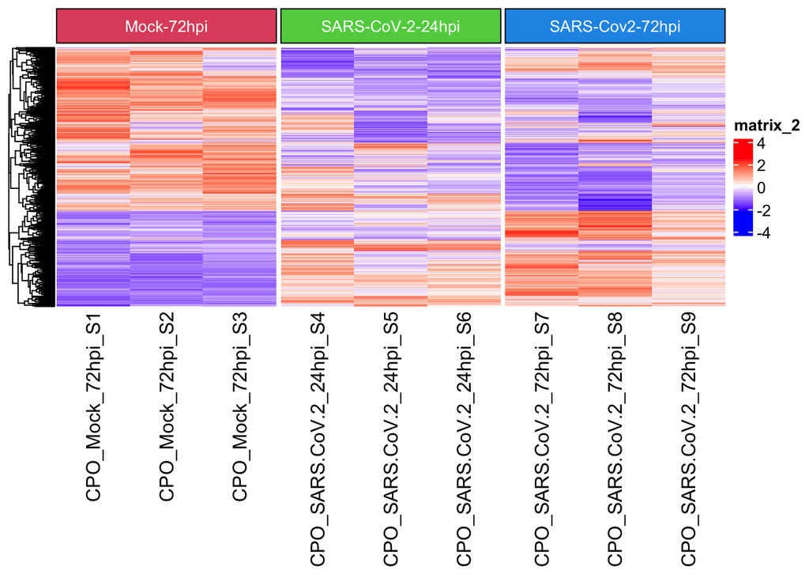

```r
heatmapMatrix <- t(scale(t(normalized_data)))

top_hits24hpi <- rownames(Cov24hpifOutputHits$table)[Cov24hpifOutputHits$table$PValue<0.05]
top_hits72hpi <- rownames(Cov72hpiOutputHits$table)[Cov72hpiOutputHits$table$PValue<0.05]

#select top hits from both groups
heatmap_matrix_tophits <- t(scale(t(heatmapMatrix[which(rownames(heatmapMatrix) %in% top_hits24hpi
                                                      | rownames(heatmapMatrix) %in% top_hits72hpi),])))

if(min(heatmap_matrix_tophits) == 0){
  heatmapCol = circlize::colorRamp2(c(min(heatmap_matrix_tophits), 0, max(heatmap_matrix_tophits)),
                                  c("blue", "white", "red"))
  } else {
    heatmapCol = circlize::colorRamp2(c(min(heatmap_matrix_tophits), 0, max(heatmap_matrix_tophits)),
                                      c("blue", "white", "red"))
  }

#heatmap annotations
ha <- ComplexHeatmap::HeatmapAnnotation(
                                   type = anno_block(gp = gpar(fill = 2:4),
                                   labels = c("Mock-72hpi", "SARS-CoV-2-24hpi", "SARS-Cov2-72hpi"),
                                   labels_gp = gpar(col = "white", fontsize = 10)))
                                   split = rep(1:3, each = 3)

heatmap <- ComplexHeatmap::Heatmap(as.matrix(heatmap_matrix_tophits),
                                   cluster_rows = TRUE,
                                   cluster_columns = FALSE,
                                   show_row_dend = TRUE,
                                   show_column_dend = FALSE,
                                   col = heatmapCol,
                                   show_column_names = TRUE,
                                   show_row_names = FALSE,
                                   show_heatmap_legend = TRUE,
                                   column_split = split,
                                   top_annotation = ha,
                                   column_title = NULL)
heatmap
```

# Thresholded Analysis

In order to perform over-representation analysis, we must first obtain all the significantly expressed genes with the threshold p-value of 0.05.

#### 1. Which method did you choose and why?

I used the quasi-likelihood results of differential expression analysis, reason is discussed above.

#### 2. What annotation data did you use and why? What version of the annotation are you using?

The annotation dataset I chose is g:profiler, this tool is widley used in bioinformatics because it provides high quality and continuously updated data.

#### 4. Run the analysis using the up-regulated set of genes, and the down-regulated set of genes separately. How do these results compare to using the whole list (i.e all differentially expressed genes together vs. the up-regulated and down regulated differentially expressed genes separately)?

```r
#export upregulated gene tables
upregulated_genes24hpi <- rownames(Cov24hpifOutputHits)[Cov24hpifOutputHits$table$PValue < 0.05 &
                                                     Cov24hpifOutputHits$table$logFC > 0]
write.table(x=upregulated_genes24hpi,file=file.path("upregulated_genes24hpi.txt"),sep = "\t",
            row.names = FALSE,col.names = FALSE,quote = FALSE)

upregulated_genes72hpi <-  rownames(Cov72hpiOutputHits)[Cov72hpiOutputHits$table$PValue < 0.05 &
                                                     Cov72hpiOutputHits$table$logFC > 0]
write.table(x=upregulated_genes72hpi,file=file.path("upregulated_genes72hpi.txt"),sep = "\t",
            row.names = FALSE,col.names = FALSE,quote = FALSE)

#export downregulated gene tables
downregulated_genes24hpi <- rownames(Cov24hpifOutputHits$table)[Cov24hpifOutputHits$table$PValue < 0.05 &
                                                             Cov24hpifOutputHits$table$logFC < 0]
write.table(x=downregulated_genes24hpi,file=file.path("downregulated_genes24hpi.txt"),sep = "\t",
            row.names = FALSE,col.names = FALSE,quote = FALSE)

downregulated_genes72hpi <- rownames(Cov72hpiOutputHits$table)[Cov72hpiOutputHits$table$PValue < 0.05 &
                                                             Cov72hpiOutputHits$table$logFC < 0]
write.table(x=downregulated_genes72hpi,file=file.path("downregulated_genes72hpi.txt"),sep = "\t",
            row.names = FALSE,col.names = FALSE,quote = FALSE)
```

[figure not shown]

Upregulated72hpi- genesets with BH FDR threshold of 0.05 GO: BP- 2,590 \ MF- 193 \ REAC: 228 \ WP: 15 \

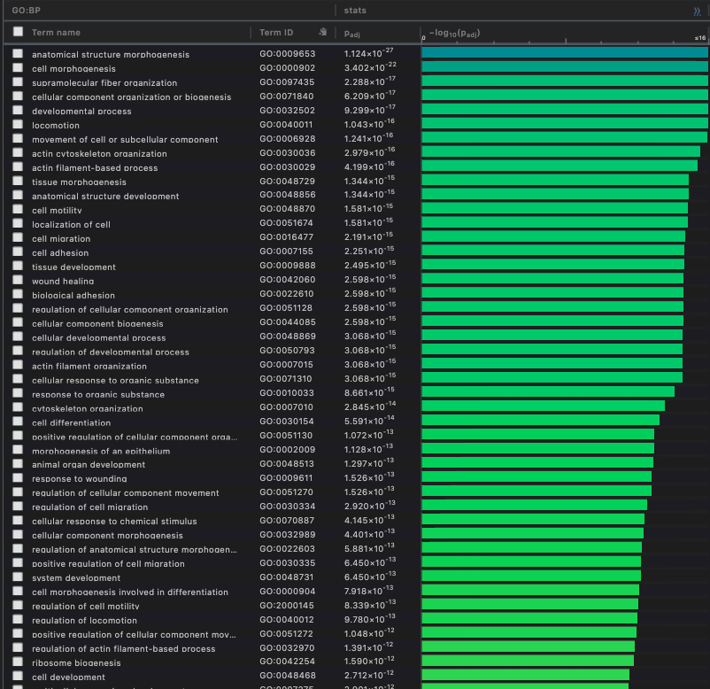

Figure 2: GO Biological Pathways for Upregulated Genes 72hpi

[figure not shown]

Downregulated72hpi- genesets with BH FDR threshold of 0.05 GO: BP- 703 \ MF- 179 \ REAC: 5 \ WP: 1 \

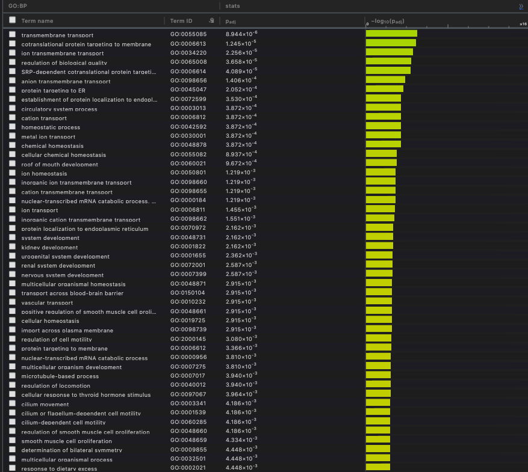

# Interpretation

#### 2. Can you find evidence, i.e. publications, to support some of the results that you see. How does this evidence support your results.

This study provides an in depth analysis of their differential gene expression with evidence from a variety of publications that supported their results. I found this to be very fascinating and also exciting that my data also corresponds to their findings.

# References

1. BCB420 2021 Course Notes; by Ruth Isserlin
2. Jacob, F., Pather, S. R., Huang, W. K., Zhang, F., Wong, S., Zhou, H., Cubitt, B., Fan, W., Chen, C. Z., Xu, M., Pradhan, M., Zhang, D. Y., Zheng, W., Bang, A. G., Song, H., Carlos de la Torre, J., & Ming, G. L. (2020). Human Pluripotent Stem Cell-Derived Neural Cells and Brain Organoids Reveal SARS-CoV-2 Neurotropism Predominates in Choroid Plexus Epithelium. Cell stem cell, 27(6), 937–950.e9. https://doi.org/10.1016/j.stem.2020.09.016
3. https://www.ncbi.nlm.nih.gov/geo/query/acc.cgi?acc=GSE157852
4. Samuels M.H. Psychiatric and cognitive manifestations of hypothyroidism. Curr. Opin. Endocrinol. Diabetes Obes. 2014;21:377–383.

# Packages Used

1. Martin Morgan (2019). BiocManager: Access the Bioconductor Project Package Repository. R package version 1.30.10. https://CRAN.R-project.org/package=BiocManager \
2. Zhu Y, Davis S, Stephens R, Meltzer PS, Chen Y. GEOmetadb: powerful alternative search engine for the Gene Expression Omnibus. Bioinformatics. 2008 Dec\ 1;24(23):2798-800. doi: 10.1093/bioinformatics/btn520. Epub 2008 Oct 7. PubMed PMID: 18842599; PubMed Central PMCID: PMC2639278.
3. Gu, Z. (2016) Complex heatmaps reveal patterns and correlations in multidimensional genomic data. Bioinformatics.\
4. Hadley Wickham, Romain François, Lionel Henry and Kirill Müller (2021). dplyr: A Grammar of Data Manipulation. R package version 1.0.5. https://CRAN.R-project.org/package=dplyr\\
5. Robinson MD, McCarthy DJ and Smyth GK (2010). edgeR: a Bioconductor package for differential expression analysis of digital gene expression data. Bioinformatics 26, 139-140 \
6. Ritchie, M.E., Phipson, B., Wu, D., Hu, Y., Law, C.W., Shi, W., and Smyth, G.K. (2015). limma powers differential expression analyses for RNA-sequencing and microarray studies. Nucleic Acids Research 43(7), e47. \
7. H. Wickham. ggplot2: Elegant Graphics for Data Analysis. Springer-Verlag New York, 2016.\
8. Hadley Wickham (2021). tidyr: Tidy Messy Data. R package version 1.1.3. https://CRAN.R-project.org/package=tidyr \
9. Gu, Z. (2014) circlize implements and enhances circular visualization in R. Bioinformatics.\
10. Yihui Xie (2021). knitr: A General-Purpose Package for Dynamic Report Generation in R. R package version 1.31. \
11. Liis Kolberg and Uku Raudvere (2020). gprofiler2: Interface to the ‘g:Profiler’ Toolset. R package version 0.2.0. https://CRAN.R-project.org/package=gprofiler2 \